# Project: Investigate a Dataset - [No-Showappointments]

- Introduction
- Data Wrangling
- Exploratory Data Analysis
- Conclusions

## Introduction

### Dataset Description

This dataset collects information from 100k medical appointments in Brazil and is focused on the question of whether or not patients show up for their appointment.

The dataset was originally sourced from Kaggle. It was created to study what factors were useful in predicting if patients would miss thier appointments. It contains basic demographic information on the patients as well as whether or not the patient received SMS notifications. In addition, it indicates if the patient received financial aid.

### Main question:

##### What factors are important for us to know in order to predict if a patient will show up for their scheduled appointment ?

To answer this question, we will be mainly looking at 5 variables with a focus on 3 of the 5 variables. First, we will compare the gender and age group with the no-show variable. Then, we will compare the variables scholarships, SMS_received, and alcoholism to the no-show variable to determine if the patient is influenced by one of the three variables stated. Lastly, we will compare the relationship between the three variables.

## Data Wrangling (Dataset dimensions, columns/ rows/ data types)

The Pandas library will be used to work with the data. The following commands will low that dataset into a pandas dataframe and display basic information about it.

### General Properties

```python
#import important Libraries
import pandas as pd
import numpy as np
import matplotlib.pyplot as plt
import seaborn as sns

% matplotlib inline
```

```python
# Load the data.
df = pd.read_csv('noshowappointments.csv')
# showing the first 5 lines of the data
df.head()
```

|  | PatientId | AppointmentID | Gender | ScheduledDay | AppointmentDay | Age | Neighbourhood | Scholarship | Hipertension | Diabetes | Alcoholism | Handcap | SMS_received | No-show |
| --- | --- | --- | --- | --- | --- | --- | --- | --- | --- | --- | --- | --- | --- | --- |
| 0 | 2.987250e+13 | 5642903 | F | 2016-04-29T18:38:08Z | 2016-04-29T00:00:00Z | 62 | JARDIM DA PENHA | 0 | 1 | 0 | 0 | 0 | 0 | No |
| 1 | 5.589978e+14 | 5642503 | M | 2016-04-29T16:08:27Z | 2016-04-29T00:00:00Z | 56 | JARDIM DA PENHA | 0 | 0 | 0 | 0 | 0 | 0 | No |
| 2 | 4.262962e+12 | 5642549 | F | 2016-04-29T16:19:04Z | 2016-04-29T00:00:00Z | 62 | MATA DA PRAIA | 0 | 0 | 0 | 0 | 0 | 0 | No |
| 3 | 8.679512e+11 | 5642828 | F | 2016-04-29T17:29:31Z | 2016-04-29T00:00:00Z | 8 | PONTAL DE CAMBURI | 0 | 0 | 0 | 0 | 0 | 0 | No |
| 4 | 8.841186e+12 | 5642494 | F | 2016-04-29T16:07:23Z | 2016-04-29T00:00:00Z | 56 | JARDIM DA PENHA | 0 | 1 | 1 | 0 | 0 | 0 | No |

###### (Hipertension & No-show&Handcap) have to be corrected

```python
df.rename(columns = {'Hipertension': 'Hypertension',
                'Handcap': 'Handicap','No-show':'No_show'}, inplace = True)
```

# Nessecary data cleaning step , as when i applied it on the data cleaning phase , it affects on my results (removing and checking the No-show duplicates)

```python
#Summary for the data
df.describe()
```

|  | PatientId | AppointmentID | Age | Scholarship | Hypertension | Diabetes | Alcoholism | Handicap | SMS_received |
| --- | --- | --- | --- | --- | --- | --- | --- | --- | --- |
| count | 1.105270e+05 | 1.105270e+05 | 110527.000000 | 110527.000000 | 110527.000000 | 110527.000000 | 110527.000000 | 110527.000000 | 110527.000000 |
| mean | 1.474963e+14 | 5.675305e+06 | 37.088874 | 0.098266 | 0.197246 | 0.071865 | 0.030400 | 0.022248 | 0.321026 |
| std | 2.560949e+14 | 7.129575e+04 | 23.110205 | 0.297675 | 0.397921 | 0.258265 | 0.171686 | 0.161543 | 0.466873 |
| min | 3.921784e+04 | 5.030230e+06 | -1.000000 | 0.000000 | 0.000000 | 0.000000 | 0.000000 | 0.000000 | 0.000000 |
| 25% | 4.172614e+12 | 5.640286e+06 | 18.000000 | 0.000000 | 0.000000 | 0.000000 | 0.000000 | 0.000000 | 0.000000 |
| 50% | 3.173184e+13 | 5.680573e+06 | 37.000000 | 0.000000 | 0.000000 | 0.000000 | 0.000000 | 0.000000 | 0.000000 |
| 75% | 9.439172e+13 | 5.725524e+06 | 55.000000 | 0.000000 | 0.000000 | 0.000000 | 0.000000 | 0.000000 | 1.000000 |
| max | 9.999816e+14 | 5.790484e+06 | 115.000000 | 1.000000 | 1.000000 | 1.000000 | 1.000000 | 4.000000 | 1.000000 |

###### The are some mistakes about age valus have to be checked and cleaned (age <= 0) , as the min= -1 .

```python
#number of columns and raws in data
df.shape
```

```
(110527, 14)
```

###### Data consists of 110527 appointments(raws) , and 14 columns

## Looking for Data that need to be cleaned

```python
#Checking for null values
df.isnull().sum()
```

```
PatientId         0
AppointmentID     0
Gender            0
ScheduledDay      0
AppointmentDay    0
Age               0
Neighbourhood     0
Scholarship       0
Hypertension      0
Diabetes          0
Alcoholism        0
Handicap          0
SMS_received      0
No_show           0
dtype: int64
```

###### As we can see there is no null values

```python
# checking the info of the data (any issues to be handeled)
df.info()
```

```
<class 'pandas.core.frame.DataFrame'>
RangeIndex: 110527 entries, 0 to 110526
Data columns (total 14 columns):
PatientId         110527 non-null float64
AppointmentID     110527 non-null int64
Gender            110527 non-null object
ScheduledDay      110527 non-null object
AppointmentDay    110527 non-null object
Age               110527 non-null int64
Neighbourhood     110527 non-null object
Scholarship       110527 non-null int64
Hypertension      110527 non-null int64
Diabetes          110527 non-null int64
Alcoholism        110527 non-null int64
Handicap          110527 non-null int64
SMS_received      110527 non-null int64
No_show           110527 non-null object
dtypes: float64(1), int64(8), object(5)
memory usage: 11.8+ MB
```

###### No missing values. AppointmentDay&AppointmentDay have to be converted to date time

```python
# check if there is a dplicates in the data
df.duplicated().sum()
```

```
0
```

###### There is no identical duplication of the raws

```python
# check the number of duplicated pateint IDs
df.duplicated("PatientId").sum()
```

```
48228
```

###### There are 48228 duplicated pateint IDs

```python
# check the number of unique values for PateintId in dataset
df.PatientId.nunique()
```

```
62299
```

###### only 62299 outof 110527 are unique values

```python
## check the number of duplicated pateint IDs and No-show
df.duplicated(["PatientId","No_show"]).sum()
```

```
38710
```

###### So we have 38710 with No-show or show same status , and have to be cleaned

```python
#check if there is an age with 0 value
df[df["Age"] == 0]
```

|  | PatientId | AppointmentID | Gender | ScheduledDay | AppointmentDay | Age | Neighbourhood | Scholarship | Hypertension | Diabetes | Alcoholism | Handicap | SMS_received | No_show |
| --- | --- | --- | --- | --- | --- | --- | --- | --- | --- | --- | --- | --- | --- | --- |
| 59 | 7.184428e+13 | 5638545 | F | 2016-04-29T08:08:43Z | 2016-04-29T00:00:00Z | 0 | CONQUISTA | 0 | 0 | 0 | 0 | 0 | 0 | No |
| 63 | 2.366233e+14 | 5628286 | M | 2016-04-27T10:46:12Z | 2016-04-29T00:00:00Z | 0 | SÃO BENEDITO | 0 | 0 | 0 | 0 | 0 | 0 | No |
| 64 | 1.885174e+14 | 5616082 | M | 2016-04-25T13:28:21Z | 2016-04-29T00:00:00Z | 0 | ILHA DAS CAIEIRAS | 0 | 0 | 0 | 0 | 0 | 1 | No |
| 65 | 2.718818e+14 | 5628321 | M | 2016-04-27T10:48:50Z | 2016-04-29T00:00:00Z | 0 | CONQUISTA | 0 | 0 | 0 | 0 | 0 | 0 | No |
| 67 | 8.647128e+13 | 5639264 | F | 2016-04-29T08:53:02Z | 2016-04-29T00:00:00Z | 0 | NOVA PALESTINA | 0 | 0 | 0 | 0 | 0 | 0 | No |
| 89 | 4.314932e+14 | 5640380 | M | 2016-04-29T10:37:02Z | 2016-04-29T00:00:00Z | 0 | MONTE BELO | 0 | 0 | 0 | 0 | 0 | 0 | No |
| 101 | 6.822847e+13 | 5642813 | M | 2016-04-29T17:24:19Z | 2016-04-29T00:00:00Z | 0 | BONFIM | 0 | 0 | 0 | 0 | 0 | 0 | No |
| 104 | 3.326985e+12 | 5632495 | F | 2016-04-28T08:04:48Z | 2016-04-29T00:00:00Z | 0 | SANTO ANTÔNIO | 0 | 0 | 0 | 0 | 0 | 0 | Yes |
| 132 | 8.468587e+14 | 5560742 | M | 2016-04-08T09:29:23Z | 2016-04-29T00:00:00Z | 0 | PRAIA DO SUÁ | 0 | 0 | 0 | 0 | 0 | 1 | Yes |
| 150 | 5.392419e+10 | 5641476 | M | 2016-04-29T13:43:34Z | 2016-04-29T00:00:00Z | 0 | ITARARÉ | 0 | 0 | 0 | 0 | 0 | 0 | No |
| 188 | 1.883366e+14 | 5640933 | M | 2016-04-29T11:44:49Z | 2016-04-29T00:00:00Z | 0 | NOVA PALESTINA | 0 | 0 | 0 | 0 | 0 | 0 | No |
| 192 | 1.165338e+12 | 5640561 | M | 2016-04-29T10:57:14Z | 2016-04-29T00:00:00Z | 0 | CONQUISTA | 0 | 0 | 0 | 0 | 0 | 0 | No |
| 193 | 2.379698e+11 | 5532452 | F | 2016-03-31T11:14:57Z | 2016-04-29T00:00:00Z | 0 | NOVA PALESTINA | 0 | 0 | 0 | 0 | 0 | 1 | No |
| 194 | 4.442538e+11 | 5539566 | M | 2016-04-01T15:17:10Z | 2016-04-29T00:00:00Z | 0 | REDENÇÃO | 0 | 0 | 0 | 0 | 0 | 0 | No |
| 250 | 2.942723e+14 | 5640181 | M | 2016-04-29T10:13:35Z | 2016-04-29T00:00:00Z | 0 | CARATOÍRA | 0 | 0 | 0 | 0 | 0 | 0 | Yes |
| 256 | 8.599713e+10 | 5629906 | F | 2016-04-27T14:19:02Z | 2016-04-29T00:00:00Z | 0 | ARIOVALDO FAVALESSA | 0 | 0 | 0 | 0 | 0 | 0 | Yes |
| 266 | 1.198173e+13 | 5639237 | M | 2016-04-29T08:50:09Z | 2016-04-29T00:00:00Z | 0 | MARIA ORTIZ | 0 | 0 | 0 | 0 | 0 | 0 | No |
| 292 | 4.645238e+13 | 5642766 | F | 2016-04-29T17:06:22Z | 2016-04-29T00:00:00Z | 0 | GURIGICA | 0 | 0 | 0 | 0 | 0 | 0 | No |
| 305 | 9.794819e+11 | 5638226 | F | 2016-04-29T07:49:54Z | 2016-04-29T00:00:00Z | 0 | JOANA D´ARC | 0 | 0 | 0 | 0 | 0 | 0 | No |
| 306 | 2.648746e+11 | 5638370 | M | 2016-04-29T07:58:15Z | 2016-04-29T00:00:00Z | 0 | SANTA MARTHA | 0 | 0 | 0 | 0 | 0 | 0 | No |
| 310 | 3.732371e+14 | 5639056 | M | 2016-04-29T08:40:58Z | 2016-04-29T00:00:00Z | 0 | SANTA MARTHA | 0 | 0 | 0 | 0 | 0 | 0 | No |
| 358 | 7.349270e+14 | 5531831 | F | 2016-03-31T10:07:18Z | 2016-04-29T00:00:00Z | 0 | CONSOLAÇÃO | 0 | 0 | 0 | 0 | 0 | 0 | Yes |
| 359 | 7.975283e+11 | 5551583 | M | 2016-04-06T14:20:30Z | 2016-04-29T00:00:00Z | 0 | CONSOLAÇÃO | 0 | 0 | 0 | 0 | 0 | 0 | No |
| 366 | 3.499167e+14 | 5531933 | F | 2016-03-31T10:14:54Z | 2016-04-29T00:00:00Z | 0 | CONSOLAÇÃO | 0 | 0 | 0 | 0 | 0 | 1 | Yes |
| 377 | 9.123627e+11 | 5522585 | M | 2016-03-29T14:39:32Z | 2016-04-29T00:00:00Z | 0 | DA PENHA | 0 | 0 | 0 | 0 | 0 | 1 | No |
| 434 | 9.625417e+14 | 5533985 | F | 2016-03-31T15:01:12Z | 2016-04-29T00:00:00Z | 0 | MORADA DE CAMBURI | 0 | 0 | 0 | 0 | 0 | 1 | Yes |
| 524 | 5.815365e+13 | 5488633 | M | 2016-03-18T10:35:28Z | 2016-04-29T00:00:00Z | 0 | ITARARÉ | 0 | 0 | 0 | 0 | 0 | 1 | No |
| 525 | 4.239228e+13 | 5537936 | F | 2016-04-01T10:53:45Z | 2016-04-29T00:00:00Z | 0 | ITARARÉ | 0 | 0 | 0 | 0 | 0 | 1 | Yes |
| 526 | 8.574376e+12 | 5639659 | M | 2016-04-29T09:22:07Z | 2016-04-29T00:00:00Z | 0 | ITARARÉ | 0 | 0 | 0 | 0 | 0 | 0 | No |
| 565 | 5.569896e+14 | 5591488 | F | 2016-04-15T17:39:38Z | 2016-04-29T00:00:00Z | 0 | SANTA LUÍZA | 0 | 0 | 0 | 0 | 0 | 1 | No |
| ... | ... | ... | ... | ... | ... | ... | ... | ... | ... | ... | ... | ... | ... | ... |
| 109629 | 3.689222e+13 | 5660428 | F | 2016-05-04T16:30:06Z | 2016-06-01T00:00:00Z | 0 | ROMÃO | 0 | 0 | 0 | 0 | 0 | 0 | Yes |
| 109633 | 3.689222e+13 | 5660427 | F | 2016-05-04T16:30:06Z | 2016-06-01T00:00:00Z | 0 | ROMÃO | 0 | 0 | 0 | 0 | 0 | 1 | Yes |
| 109646 | 5.941811e+13 | 5659194 | M | 2016-05-04T13:21:32Z | 2016-06-01T00:00:00Z | 0 | FORTE SÃO JOÃO | 0 | 0 | 0 | 0 | 0 | 0 | No |
| 109647 | 5.635258e+13 | 5691391 | M | 2016-05-12T12:35:04Z | 2016-06-08T00:00:00Z | 0 | FORTE SÃO JOÃO | 0 | 0 | 0 | 0 | 0 | 0 | Yes |
| 109649 | 5.941811e+13 | 5659193 | M | 2016-05-04T13:21:32Z | 2016-06-01T00:00:00Z | 0 | FORTE SÃO JOÃO | 0 | 0 | 0 | 0 | 0 | 0 | No |
| 109650 | 5.635258e+13 | 5691390 | M | 2016-05-12T12:35:04Z | 2016-06-08T00:00:00Z | 0 | FORTE SÃO JOÃO | 0 | 0 | 0 | 0 | 0 | 0 | Yes |
| 109830 | 6.931429e+11 | 5739239 | F | 2016-05-25T13:07:38Z | 2016-06-02T00:00:00Z | 0 | SÃO BENEDITO | 0 | 0 | 0 | 0 | 0 | 0 | Yes |
| 109847 | 9.174483e+11 | 5685977 | M | 2016-05-11T11:33:48Z | 2016-06-02T00:00:00Z | 0 | NOVA PALESTINA | 0 | 0 | 0 | 0 | 0 | 1 | Yes |
| 109848 | 5.853540e+12 | 5707361 | M | 2016-05-17T09:32:32Z | 2016-06-02T00:00:00Z | 0 | RESISTÊNCIA | 0 | 0 | 0 | 0 | 0 | 0 | No |
| 109852 | 1.663316e+13 | 5731578 | F | 2016-05-24T10:14:26Z | 2016-06-02T00:00:00Z | 0 | RESISTÊNCIA | 0 | 0 | 0 | 0 | 0 | 0 | No |
| 110231 | 1.731548e+14 | 5634706 | M | 2016-04-28T11:32:00Z | 2016-06-01T00:00:00Z | 0 | RESISTÊNCIA | 0 | 0 | 0 | 0 | 0 | 0 | No |
| 110235 | 3.279373e+14 | 5634274 | M | 2016-04-28T10:40:49Z | 2016-06-01T00:00:00Z | 0 | RESISTÊNCIA | 0 | 0 | 0 | 0 | 0 | 0 | Yes |
| 110236 | 1.174717e+13 | 5669996 | M | 2016-05-06T12:31:22Z | 2016-06-08T00:00:00Z | 0 | RESISTÊNCIA | 0 | 0 | 0 | 0 | 0 | 1 | No |
| 110299 | 5.944513e+10 | 5746323 | F | 2016-05-30T13:47:40Z | 2016-06-07T00:00:00Z | 0 | RESISTÊNCIA | 0 | 0 | 0 | 0 | 0 | 1 | Yes |
| 110313 | 8.535734e+12 | 5600209 | F | 2016-04-19T10:09:05Z | 2016-06-06T00:00:00Z | 0 | RESISTÊNCIA | 0 | 0 | 0 | 0 | 0 | 1 | No |
| 110319 | 4.524190e+11 | 5640301 | F | 2016-04-29T10:28:16Z | 2016-06-06T00:00:00Z | 0 | RESISTÊNCIA | 0 | 0 | 0 | 0 | 0 | 1 | No |
| 110320 | 3.459268e+13 | 5675103 | M | 2016-05-09T13:02:20Z | 2016-06-06T00:00:00Z | 0 | RESISTÊNCIA | 0 | 0 | 0 | 0 | 0 | 1 | No |
| 110321 | 1.388630e+11 | 5338643 | M | 2016-02-11T16:14:32Z | 2016-06-01T00:00:00Z | 0 | RESISTÊNCIA | 0 | 0 | 0 | 0 | 0 | 1 | No |
| 110331 | 2.739486e+13 | 5392089 | F | 2016-02-24T15:33:08Z | 2016-06-01T00:00:00Z | 0 | RESISTÊNCIA | 0 | 0 | 0 | 0 | 0 | 1 | Yes |
| 110334 | 1.174717e+13 | 5756343 | M | 2016-06-01T08:12:55Z | 2016-06-01T00:00:00Z | 0 | RESISTÊNCIA | 0 | 0 | 0 | 0 | 0 | 0 | No |
| 110335 | 3.747953e+11 | 5338761 | M | 2016-02-11T16:39:26Z | 2016-06-01T00:00:00Z | 0 | RESISTÊNCIA | 0 | 0 | 0 | 0 | 0 | 1 | No |
| 110339 | 3.731746e+12 | 5584042 | M | 2016-04-14T13:01:21Z | 2016-06-01T00:00:00Z | 0 | RESISTÊNCIA | 0 | 0 | 0 | 0 | 0 | 1 | Yes |
| 110341 | 4.696832e+12 | 5713894 | M | 2016-05-18T10:55:00Z | 2016-06-01T00:00:00Z | 0 | RESISTÊNCIA | 0 | 0 | 0 | 0 | 0 | 1 | No |
| 110342 | 3.147163e+11 | 5776749 | M | 2016-06-06T11:48:00Z | 2016-06-08T00:00:00Z | 0 | RESISTÊNCIA | 0 | 0 | 0 | 0 | 0 | 0 | No |
| 110343 | 1.759439e+12 | 5690822 | F | 2016-05-12T10:43:50Z | 2016-06-01T00:00:00Z | 0 | RESISTÊNCIA | 0 | 0 | 0 | 0 | 0 | 1 | No |
| 110345 | 1.473952e+14 | 5702537 | F | 2016-05-16T12:30:58Z | 2016-06-01T00:00:00Z | 0 | RESISTÊNCIA | 0 | 0 | 0 | 0 | 0 | 0 | No |
| 110346 | 5.577525e+12 | 5777724 | M | 2016-06-06T14:22:34Z | 2016-06-08T00:00:00Z | 0 | RESISTÊNCIA | 0 | 0 | 0 | 0 | 0 | 0 | No |
| 110454 | 6.142460e+11 | 5772400 | F | 2016-06-03T15:18:44Z | 2016-06-03T00:00:00Z | 0 | RESISTÊNCIA | 0 | 0 | 0 | 0 | 0 | 0 | No |
| 110460 | 4.321846e+13 | 5769545 | F | 2016-06-03T08:56:51Z | 2016-06-03T00:00:00Z | 0 | RESISTÊNCIA | 0 | 0 | 0 | 0 | 0 | 0 | No |
| 110507 | 4.769462e+14 | 5786918 | F | 2016-06-08T09:04:18Z | 2016-06-08T00:00:00Z | 0 | MARIA ORTIZ | 0 | 0 | 0 | 0 | 0 | 0 | No |

3539 rows × 14 columns

###### There are 3539 ages = 0 , It have to be handeled

```python
# check the
#check if there is an age with 0 value
df[df["Age"] < 0]
```

|  | PatientId | AppointmentID | Gender | ScheduledDay | AppointmentDay | Age | Neighbourhood | Scholarship | Hypertension | Diabetes | Alcoholism | Handicap | SMS_received | No_show |
| --- | --- | --- | --- | --- | --- | --- | --- | --- | --- | --- | --- | --- | --- | --- |
| 99832 | 4.659432e+14 | 5775010 | F | 2016-06-06T08:58:13Z | 2016-06-06T00:00:00Z | -1 | ROMÃO | 0 | 0 | 0 | 0 | 0 | 0 | No |

###### The patient No. 99832 has -1 age , and have to be dropped

## Data Cleaning

###### # Convert AppointmentDay to datetime type

```python
df.AppointmentDay = pd.to_datetime(df.AppointmentDay)
df.AppointmentDay.head(2)
```

```
0   2016-04-29
1   2016-04-29
Name: AppointmentDay, dtype: datetime64[ns]
```

###### # Convert ScheduledDay to datetime type

```python
df.ScheduledDay = pd.to_datetime(df.ScheduledDay)
df.ScheduledDay.head(2)
```

```
0   2016-04-29 18:38:08
1   2016-04-29 16:08:27
Name: ScheduledDay, dtype: datetime64[ns]
```

###### Removing the -1 age for patient No. 99832

```python
df.drop(df.index[99832],inplace= True)
```

###### fixing the ages that = 0 by taking the mean of all ages and put those values into it

```python
MeanAge = df['Age'].mean()
df[df['Age'] == 0] = MeanAge
```

###### Removing duplicated IDS with duplicated showing status

```python
df.drop_duplicates(["PatientId","No_show"],inplace= True)
```

```python
df.shape
```

```
(69455, 14)
```

###### Removing soma data that may be not nessesary

```python
# Create new dataset without unwanted columns
clean_appointment_data = df.drop(['PatientId','ScheduledDay','AppointmentID','AppointmentDay'], axis=1)
clean_appointment_data.head()
```

|  | Gender | Age | Neighbourhood | Scholarship | Hypertension | Diabetes | Alcoholism | Handicap | SMS_received | No_show |
| --- | --- | --- | --- | --- | --- | --- | --- | --- | --- | --- |
| 0 | F | 62.0 | JARDIM DA PENHA | 0.0 | 1.0 | 0.0 | 0.0 | 0.0 | 0.0 | No |
| 1 | M | 56.0 | JARDIM DA PENHA | 0.0 | 0.0 | 0.0 | 0.0 | 0.0 | 0.0 | No |
| 2 | F | 62.0 | MATA DA PRAIA | 0.0 | 0.0 | 0.0 | 0.0 | 0.0 | 0.0 | No |
| 3 | F | 8.0 | PONTAL DE CAMBURI | 0.0 | 0.0 | 0.0 | 0.0 | 0.0 | 0.0 | No |
| 4 | F | 56.0 | JARDIM DA PENHA | 0.0 | 1.0 | 1.0 | 0.0 | 0.0 | 0.0 | No |

# Data Exploration And Visualization

###### The ratio between males and females

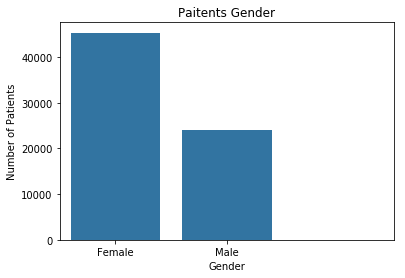

```python
# plot a bar chart
sns.countplot(data = df, x = 'Gender', color = base_color)
plt.title('Paitents Gender')
plt.xticks([0, 1], ['Female', 'Male'])
plt.xlabel('Gender')
plt.ylabel('Number of Patients');
```

Most patients were females.

###### The ratio between show and no show

```python
# check value counts in no_show column
df.No_show.value_counts()
```

```
No                    52360
Yes                   17094
37.089218826339504        1
Name: No_show, dtype: int64
```

```python
# if the value Yes then change it to 1, otherwise 0
df.No_show = np.where(df.No_show == "Yes", 1, 0)
# confirm
df.No_show.value_counts()
```

```
0    52361
1    17094
Name: No_show, dtype: int64
```

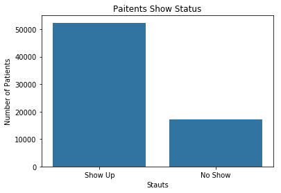

```python
# plot a bar chart
base_color = sns.color_palette()[0]
sns.countplot(data = df, x = 'No_show', color = base_color)
plt.title('Paitents Show Status')
plt.xticks([0, 1], ['Show Up', 'No Show'])
plt.xlabel('Stauts')
plt.ylabel('Number of Patients');
```

```
Text(0.5,1,'Paitents Show Status')
```

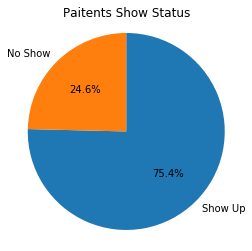

```python
# plot a pie chart
sorted_counts = df.No_show.value_counts()
plt.pie(sorted_counts, labels = ['Show Up', 'No Show'], startangle = 90,
        counterclock = False, autopct='%1.1f%%');
plt.axis('square')
plt.title('Paitents Show Status')
```

Most patients showed up for their appointments (75.4%). No. of showed patients aprroimately 3 times greater than non-showed

###### Q1) is there relation between Gender and people who not showed up (not came to thier appointment ) ?

```python
df.groupby(["No_show", "Gender"]).size()
```

```
No_show  Gender
0        37.089218826339504        1
         F                     34106
         M                     18254
1        F                     11226
         M                      5868
dtype: int64
```

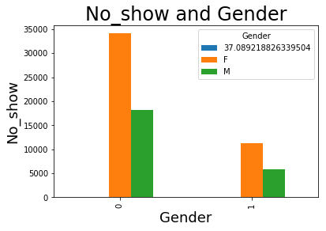

```python
# Plot a bar graph based on groupby data
groups = df.groupby(['No_show','Gender']).size().unstack(fill_value=0)
groups.plot.bar()

# Set titles and axes
plt.title('No_show and Gender', fontsize = 24)
plt.xlabel('Gender', fontsize=18)
plt.ylabel('No_show', fontsize=18)
plt.show()
```

[figure not shown]

```python
# pie chart properties
labels = 'Female, No show', 'Female, Showed', 'Male, No Show', 'Male, Show'
cut_points = [57245, 14594, 30962, 7725 ]
colors = ['pink', 'orange', 'blue', 'green']

# piechart title and axis
fig1, ax = plt.subplots()
ax.pie(cut_points, labels=labels, colors=colors, autopct='%1.1f%%',shadow=True)
plt.title('Proportion of Female and Male Patients', fontsize= 18)

# Pie is shown as a circle once the aspect ratio is equal.
ax.axis('equal')

#plot
plt.show()
```

###### Q2) is there realtion between the age and the people who not came to thier appointment ?

```
Age
1.0      0.225650
2.0      0.186712
3.0      0.214620
4.0      0.248672
5.0      0.254286
6.0      0.250000
7.0      0.235722
8.0      0.260600
9.0      0.293200
10.0     0.271531
11.0     0.244694
12.0     0.279039
13.0     0.289125
14.0     0.302613
15.0     0.288030
16.0     0.279020
17.0     0.296259
18.0     0.282869
19.0     0.278203
20.0     0.286015
21.0     0.291282
22.0     0.316777
23.0     0.292906
24.0     0.305226
25.0     0.308390
26.0     0.291962
27.0     0.303532
28.0     0.292341
29.0     0.289357
30.0     0.280538
           ...
73.0     0.168443
74.0     0.183673
75.0     0.178161
76.0     0.187668
77.0     0.189112
78.0     0.206304
79.0     0.188462
80.0     0.198113
```

[output cut: 8 more lines]

```
89.0     0.188679
90.0     0.260870
91.0     0.255814
92.0     0.218182
93.0     0.235294
94.0     0.260870
95.0     0.250000
96.0     0.066667
97.0     0.222222
98.0     0.200000
99.0     0.000000
100.0    0.000000
102.0    0.000000
115.0    0.333333
Name: No_show, Length: 103, dtype: float64
```

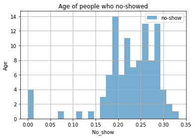

```python
# using group by function to find relations between features
# visualize the average of people who came + print the percentage

df.groupby('Age')['No_show'].mean().hist(alpha=0.6,bins=25,label='no-show');
plt.xlabel("No_show")
plt.ylabel("Age")
plt.title("Age of people who no-showed")
plt.legend()
df.groupby('Age')['No_show'].mean()
```

We can compute the value of patients who did not show up for appointments by visualizing only the Age variable. We may deduce from the data returned by the group-by function that there really are roughly an equal number of patients that show up for their appointments from youth to retirement. This means that the number of no-show patients in each age group, from childhood to retirement, will reveal the number of patients that won't show up for an appointment.

###### Q3) is there realtion between the alcholism and the people who not came to thier appointment ?

```python
df.groupby(["No_show", "Alcoholism"]).size()
```

```
No_show  Alcoholism
0        0.000000      51082
         1.000000       1278
         37.089219         1
1        0.000000      16574
         1.000000        520
dtype: int64
```

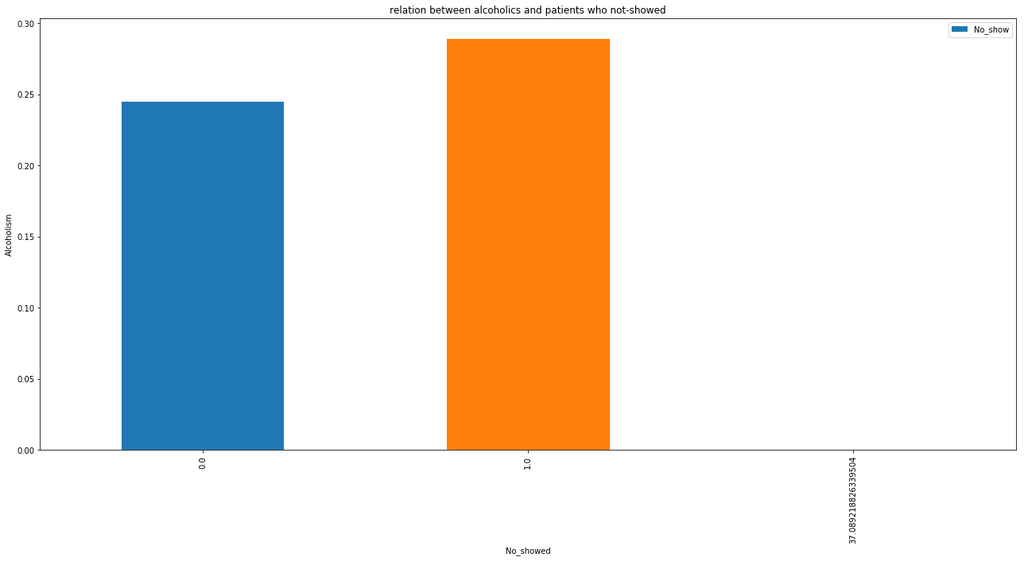

```python
df.groupby('Alcoholism')['No_show'].mean().plot(kind='bar',figsize=(22,10));
plt.xlabel("No_showed")
plt.ylabel("Alcoholism")
plt.title("relation between alcoholics and patients who not-showed")
plt.legend()
```

###### Q4) is there realtion between having an SMS and the people who not came to thier appointment ?

```python
df.groupby(["No_show", "SMS_received"]).size()
```

```
No_show  SMS_received
0        0.000000        36712
         1.000000        15648
         37.089219           1
1        0.000000         9283
         1.000000         7811
dtype: int64
```

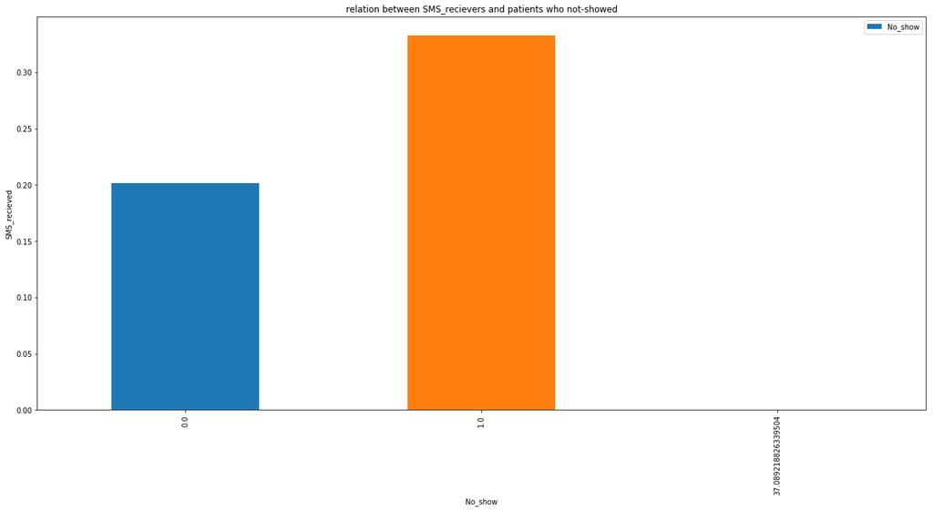

```python
df.groupby('SMS_received')['No_show'].mean().plot(kind='bar',figsize=(22,10));
plt.xlabel("No_show")
plt.ylabel("SMS_recieved")
plt.title("relation between SMS_recievers and patients who not-showed")
plt.legend()
```

###### Q5) is there realtion between Scholarship and the people who not came to thier appointment ?

```python
df.No_show.value_counts()
```

```
0    52361
1    17094
Name: No_show, dtype: int64
```

```python
df.Scholarship.value_counts()
```

```
0.000000     62629
1.000000      6825
37.089219        1
Name: Scholarship, dtype: int64
```

```python
df.groupby(["No_show", "Scholarship"]).size()
```

```
No_show  Scholarship
0        0.000000       47443
         1.000000        4917
         37.089219          1
1        0.000000       15186
         1.000000        1908
dtype: int64
```

```
Scholarship
0.000000     0.242476
1.000000     0.279560
37.089219    0.000000
Name: No_show, dtype: float64
```

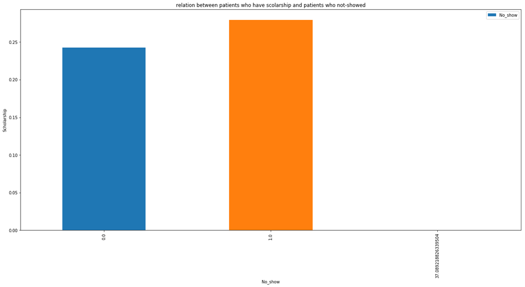

```python
print(df.groupby('Scholarship')['No_show'].mean())
df.groupby('Scholarship')['No_show'].mean().plot(kind = 'bar',figsize=(22,10))
plt.xlabel("No_show")
plt.ylabel("Scholarship")
plt.title("relation between patients who have scolarship and patients who not-showed")
plt.legend()
```